# Phenology Flagging

Megan Vahsen

2023-04-17

## Description of flags

This document details the code that informs how phenology data from the Bromecast 2022 experiments are flagged. The functions that are used to flag the phenology data are in the file “QAQC_functions.R” and are described in detail below.

### Late emergence

Notes if the plant emerged after the first date plants were assessed for emergence, and if so, records the date of the visit where emergence was first observed. NAs for plants with recorded emergence on the first visit and for plants that never emerged.

```r
flag_lateemergence <- function(plant_data){
  # was plant absent first visit, later present?
  if(plant_data$live[1]=="Y"){
    return(NA)  # emergence on first visit
  }else if(sum(plant_data$live=="Y")==0){
    return(NA)  # never emerged
  }else{
    # return date of first recorded presence
    tmp <- which(plant_data$live=="Y")
    if(length(tmp)>1) tmp <- tmp[1]
    return(plant_data$jday[tmp])
  }
}
```

### Emergence date

Records emergence date. NAs for plants that never emerged.

```r
get_emergence_date <- function(plant_data){
  # date of first presence
  if(sum(plant_data$live=="Y")==0){
    return(NA)  # never emerged
  }else{
    # return date of first presence
    tmp <- which(plant_data$live=="Y")
    if(length(tmp)>1) tmp <- tmp[1]
    return(plant_data$jday[tmp])
  }
}
```

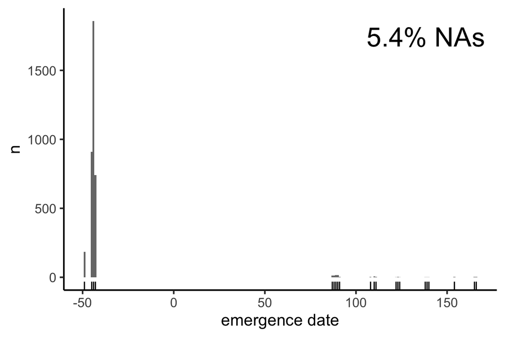

### Death date

Records first date for which there absence recorded following a presence being recorded. Returns NAs if plants were alive and never died or if plants never emerged to begin with.

```r
get_death_date <- function(plant_data){
  # date of first absence after a presence
  out <- NA  # death not observed
  tmp <- ifelse(plant_data$live=="Y",1,0)
  tmp <- diff(tmp)
  deaths <- which(tmp==-1)
  if(length(deaths)>0){
      out <- plant_data$jday[1+min(deaths)]
  }
  return(out)
}
```

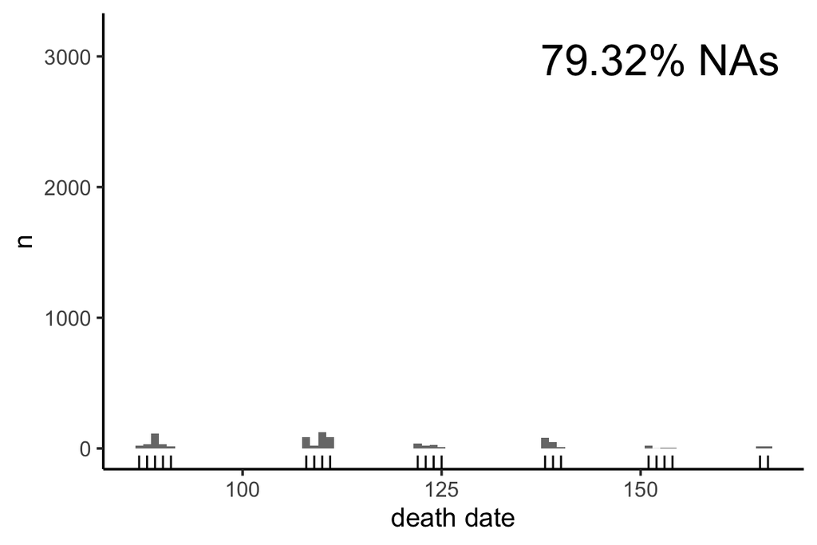

### Resurrection

Records if plant was recorded as being present after previously being recorded as absent. Returns NAs if plants were never recorded as absent after being present or if plants never emerged to being with.

```r
flag_resurrection <- function(plant_data){
  # was plant observed alive after being observed dead?
  out <- NA
  tmp <- ifelse(plant_data$live=="Y",1,0)
  tmp <- diff(tmp)
  births <- which(tmp==1)
  deaths <- which(tmp==-1)
  if(length(births)>0 & length(deaths)>0){
    if(max(births)>min(deaths)){
      out <- plant_data$jday[1+max(births)]
    }
  }
  return(out)
}
```

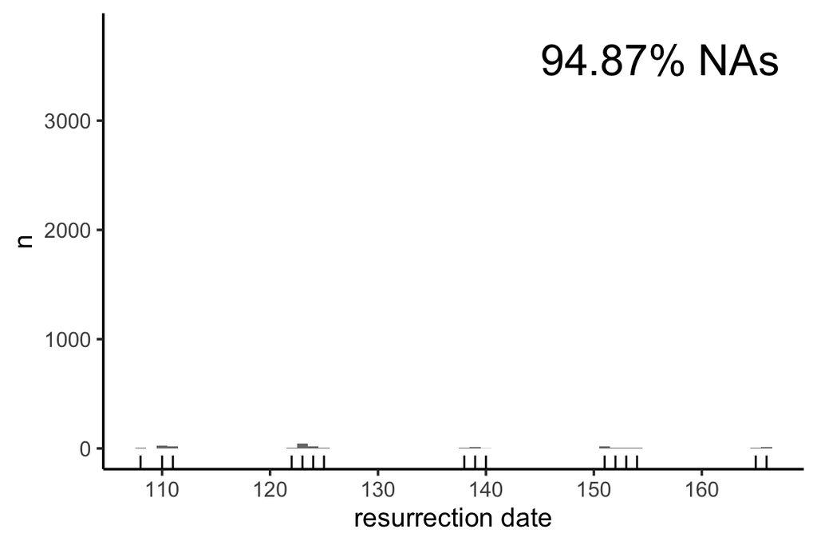

### Phenological regression

Determines if phenology goes backwards through time (*e.g.*, V1 recorded after a previously recorded V2) and if so, records the maximum number of stages of regression for each plant. Returns NAs if phenological regression doesn’t happen or if the plant never emerged to being with.

```r
flag_phenoregress <- function(plant_data,pheno_table){
  # does phenology go backwards? returns how # of stages of regression
  out <- NA
  if(sum(plant_data$live=="Y")>1){
    plant_data <- merge(plant_data,pheno_table)
    plant_data <- plant_data[order(plant_data$jday),]
    tmp <- diff(plant_data$v_numeric)
    if(min(tmp)<0) out <- min(tmp)
  }
  return(out)
}
```

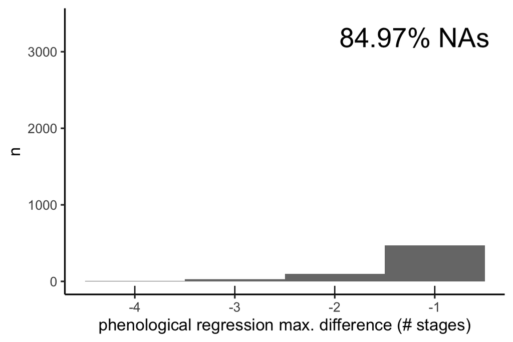

### Growth regression

Determines if the leaf length of the plant goes backwards through time and if so, records the maximum amount of shrinkage in millimeters. Records NAs if there is no growth regression or if plant did not emerge to begin with.

```r
flag_growthregress <- function(plant_data){
  # does leaf length go backwards? return max mm of shrinkage
  out <- NA
  if(sum(!is.na(plant_data$length_mm)>1)){
    tmp <- diff(plant_data$length_mm)
    if(sum(!is.na(tmp)>0)){
       if(min(tmp,na.rm=T)<0) out <- min(tmp,na.rm=T)
    }
  }
  return(out)
}
```

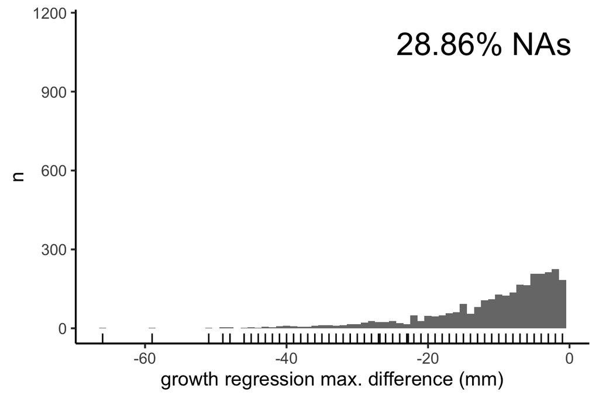

### Frost heave

Determines if there was frost heave recorded for the plant and if so, returns the date of first recorded frost heave. Returns NAs if no frost heave recorded for the plant or if the plant never emerged to begin with. Also adds notes to observation about frost heave.

```r
flag_frostheave <- function(plant_data){
  out <- NA
  # date of first frost heave
  tmp <- which(plant_data$frost_heave=="Y")
  # add notes about frostheave
  tmp <- c(tmp,which(plant_data$standard_note=="frostheave"))
  # return date
  if(length(tmp)>0){
    tmp <- min(tmp)
    out <- plant_data$jday[tmp]
  }
  return(out)
}
```

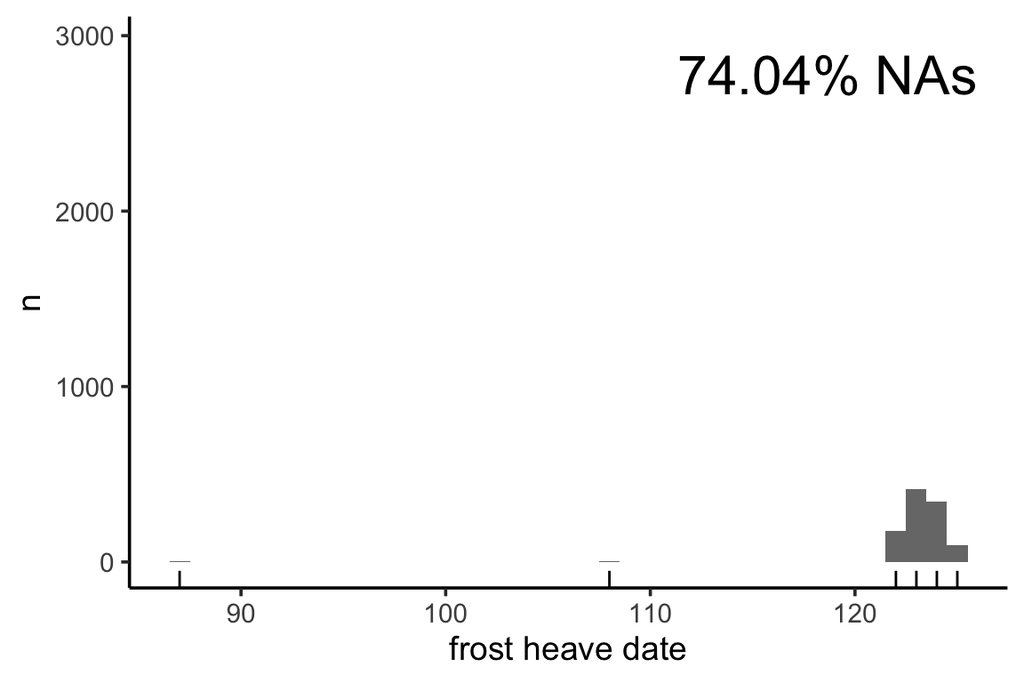

### Herbivory

Determines if there was herbivory recorded for the plant and if so, returns the date for which herbivory was first recorded. Returns NAs if there was no herbivory recorded or if plants never emerged to begin with. Also adds notes to observation about herbivory.

```r
flag_herbivory <- function(plant_data){
  out <- NA
  # date of first herbivory observation
  tmp <- which(plant_data$herbivory=="Y")
  # add notes about herbivory
  tmp <- c(tmp,which(plant_data$standard_note=="herbivory"))
  # return date
  if(length(tmp)>0){
    tmp <- min(tmp)
    out <- plant_data$jday[tmp]
  }
  return(out)
}
```

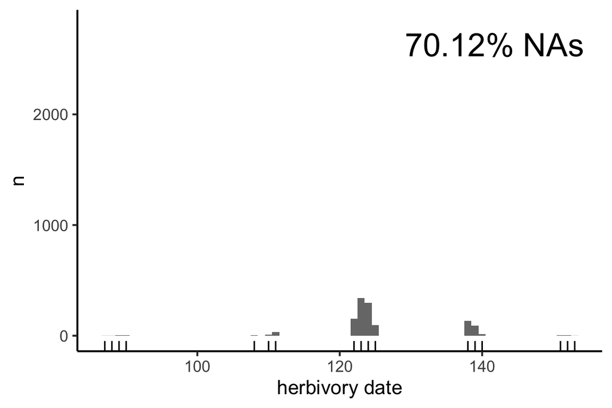

### Bad position

Determines if the plant was not in the expected position and if so, returns the date for which “bad position” was first recorded. Returns NAs if there was no “bad position: recorded or if plants never emerged to begin with. Also adds notes to observation about bad positioning.

```r
flag_badposition <- function(plant_data){
  out <- NA
  # date of bad position observation
  tmp <- which(plant_data$standard_note=="badposition")
  if(length(tmp)>0){
    tmp <- min(tmp)
    out <- plant_data$jday[tmp]
  }
  return(out)
}
```

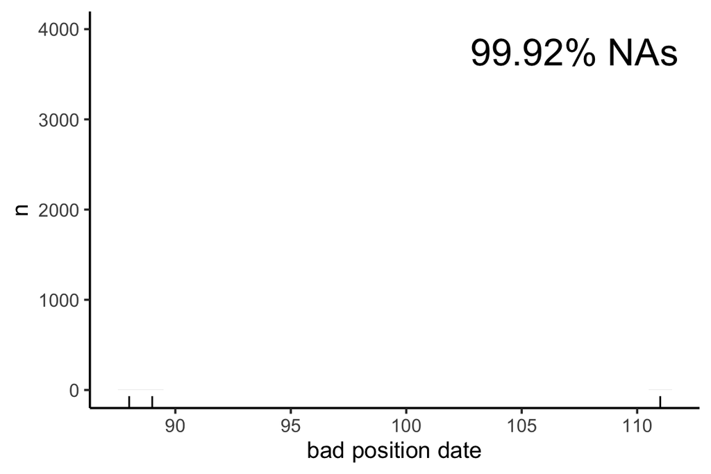

### Other notes

Determines if there are other standardized notes that are important to add to the derived data that are not herbivory, frost heave, or bad positioning, and if so, records them. If there are multiple notes, these are combined together. Returns NAs if there are no other notes.

```r
flag_other <- function(plant_data){
  out <- NA
  # include other consequential notes
  tmp <- which(!is.na(plant_data$standard_note))
  if(length(tmp)>0){
    # remove frostheave, herbivory and badposition (these dealt with separately)
    tmp <- plant_data$standard_note[tmp]
    notes <- tmp[which(tmp != "herbivory" & tmp != "frostheave" & tmp != "badposition")]
    if(length(notes)>0){
      notes <- unique(notes)  # prevent duplicates
      notes <- paste(notes,collapse='-') # if multiple notes, combine
      out <- notes
    }
  }
  return(out)
}
```

```
## # A tibble: 4 × 3
##   other              n percentage
##   <chr>          <int>      <dbl>
## 1 lateflowers        1      0.025
## 2 physicaldamage     3      0.075
## 3 smut               1      0.025
## 4 <NA>            3994     99.9
```

## Running analyses to see the impact of flagging on inference

### Assessing survival rates

```
## # A tibble: 3 × 5
##   component      variance std_dev lower_ci upper_ci
##   <chr>             <dbl>   <dbl>    <dbl>    <dbl>
## 1 s(block)         0.0520   0.228   0.0700    0.743
## 2 s(plot_unique)   0.227    0.476   0.335     0.675
## 3 s(genotype)      0.0377   0.194   0.0986    0.383
```

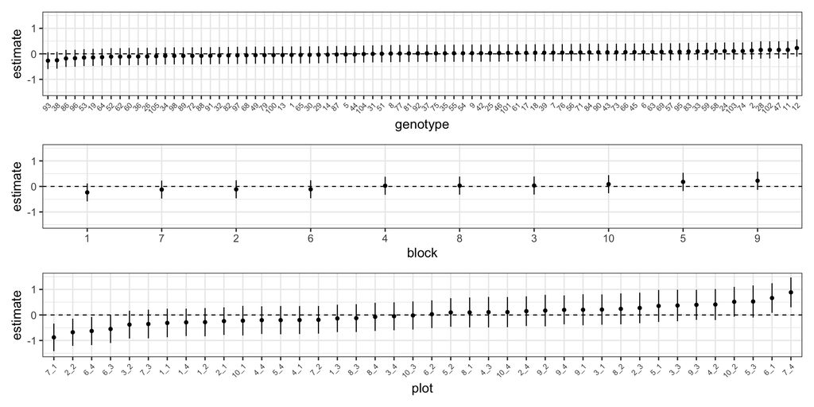

Variation in likelihood of survival is mostly driven by small, plot-level variation rather than large, block-level variation or genotypic variation.

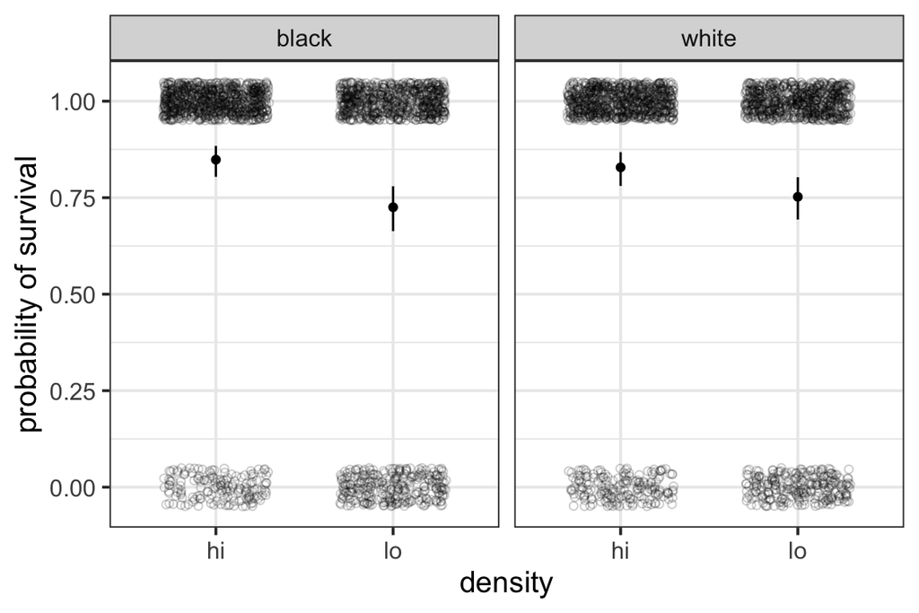

The likelihood of survival is higher at high density than at low density, and this effect is consistent across gravel types.

### Assessing flowering rates (i.e., if flowered or not, based on plants that survived)

```
## # A tibble: 3 × 5
##   component      variance std_dev lower_ci upper_ci
##   <chr>             <dbl>   <dbl>    <dbl>    <dbl>
## 1 s(block)         0.286    0.535 0.264        1.08
## 2 s(plot_unique)   0.0290   0.170 0.000458    63.1
## 3 s(genotype)      1.51     1.23  0.893        1.70
```

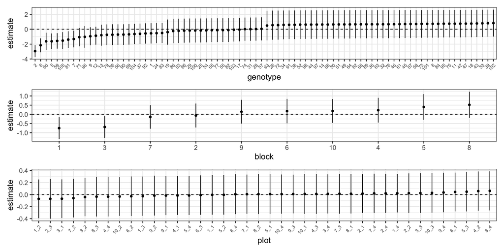

Variation in likelihood of flower (given that a plant survived) is mostly driven by genotypic variation rather than plot- or block-level variation.

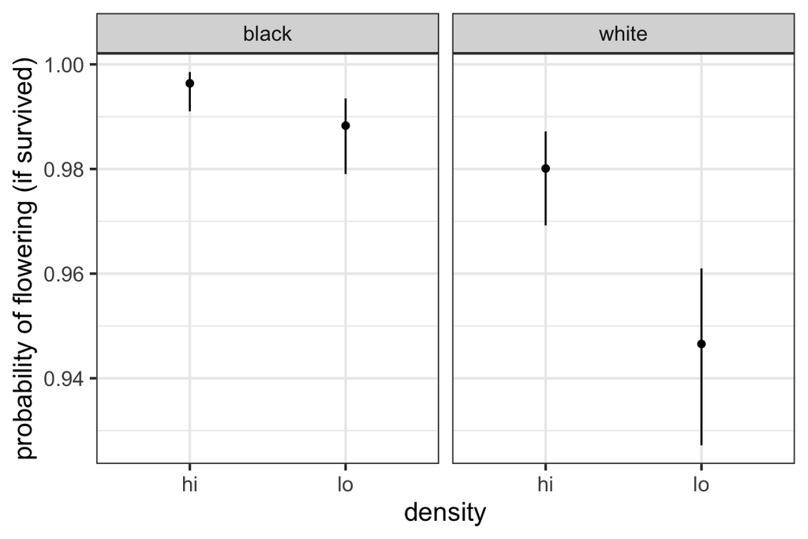

The probability of flowering is higher at high density than at low density and higher when the plant is in black gravel compared to white gravel.

## Assessing time to flower

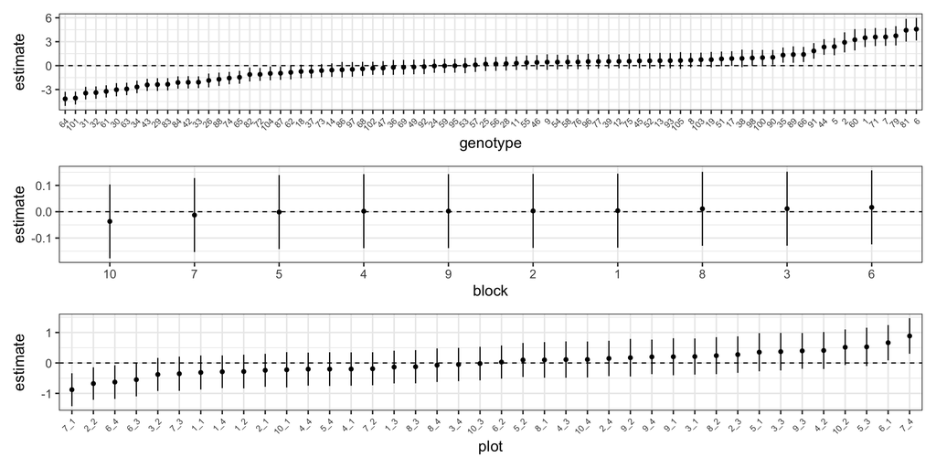

Variation in the timing of flowering is mostly driven by genotypic variation, but also by small, plot-level variation.

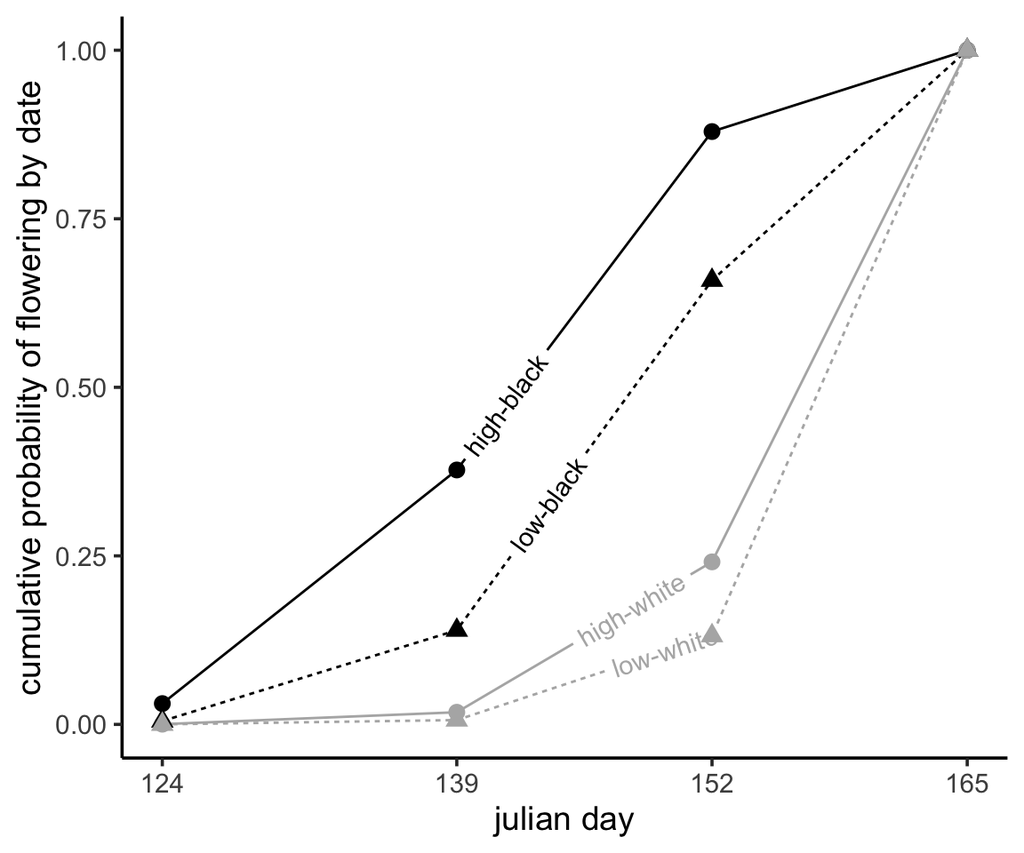

Plants flower earlier when at a higher density than at a lower density, and flower earlier in black gravel than in white gravel. The effect of density on flowering time is greater when plants are in black gravel than when plants are in white gravel.